# Practical Homework I

Richa

2025-04-03

## PRACTICAL HOMEWORK 1: DECISION TREES

#### In this project, we are going to apply our knowledge of Decision Trees. We will be modelling single trees, pruning them, using ensemble methods like bagging, boosting and randomForests to explore and analyse youth drug use. The data given is very large (10,561 rows!) and has a lot of variabes (79!). Since we will not be using all of the variables, cleaning and factorsing variables of our choice will be smarter than cleaning all columns of the dataset.

##### For this assignment, I have decided to focus on the question “IMPACT OF FAMILY BACKGROUND AND SOCIOECONOMIC STATUS ON MARIJUANA USE”. We have around 15-20 variables of interest, which we will see throughout this assignment.

```r
#Importing Libraries
library(dplyr)
library(tidyr)
library(tree)
library(caret)
```

```r
library(ggplot2)
library(randomForest)
library(gbm)
#Loading the Data
load("/Users/rich/Downloads/youth_data.Rdata")
View(df)

#Exploring the Data
ncol(df)
```

```
## [1] 79
```

```r
nrow(df)
```

```
## [1] 10561
```

```r
str(df)
```

```
## 'data.frame':    10561 obs. of  79 variables:
##  $ IRALCFY    : num  991 991 1 991 991 991 991 993 991 991 ...
##   ..- attr(*, "label")= chr "ALCOHOL FREQUENCY PAST YEAR - IMPUTATION REVISED"
##   ..- attr(*, "format.sas")= chr "IRALCFYFMT"
##  $ IRMJFY     : num  991 60 991 991 991 991 991 991 991 991 ...
##   ..- attr(*, "label")= chr "MARIJUANA FREQUENCY PAST YEAR - IMPUTATION REVISED"
##   ..- attr(*, "format.sas")= chr "IRMJFYFMT"
##  $ IRCIGFM    : num  91 91 91 91 91 91 91 91 91 91 ...
##   ..- attr(*, "label")= chr "CIG FREQUENCY PAST MONTH - IMPUTATION REVISED"
##   ..- attr(*, "format.sas")= chr "IRCIGFMFMT"
##  $ IRSMKLSS30N: num  91 91 91 91 91 91 91 91 91 91 ...
##   ..- attr(*, "label")= chr "SMOKELESS TOBACCO FREQUENCY PAST MONTH - IMPUTATION REVISED"
##   ..- attr(*, "format.sas")= chr "IRSMKLSS30NFMT"
##  $ IRALCFM    : num  91 91 93 91 91 91 91 93 91 91 ...
##   ..- attr(*, "label")= chr "ALCOHOL FREQUENCY PAST MONTH - IMPUTATION REVISED"
##   ..- attr(*, "format.sas")= chr "IRALCFMFMT"
##  $ IRMJFM     : num  91 2 91 91 91 91 91 91 91 91 ...
##   ..- attr(*, "label")= chr "MARIJUANA FREQUENCY PAST MONTH - IMPUTATION REVISED"
##   ..- attr(*, "format.sas")= chr "IRMJFMFMT"
##  $ IRCIGAGE   : num  991 991 991 991 991 991 991 991 991 991 ...
##   ..- attr(*, "label")= chr "CIGARETTE AGE OF FIRST USE - IMPUTATION REVISED"
##   ..- attr(*, "format.sas")= chr "IRCIGAGEFMT"
##  $ IRSMKLSSTRY: num  991 991 991 991 991 991 991 991 991 991 ...
##   ..- attr(*, "label")= chr "SMOKELESS TOBACCO AGE OF FIRST USE - IMPUTATION REVISED"
##   ..- attr(*, "format.sas")= chr "IRSMKLSSTRYFMT"
##  $ IRALCAGE   : num  991 991 11 991 991 991 991 12 991 991 ...
##   ..- attr(*, "label")= chr "ALCOHOL AGE OF FIRST USE - IMPUTATION REVISED"
##   ..- attr(*, "format.sas")= chr "IRALCAGEFMT"
##  $ IRMJAGE    : num  991 14 991 991 991 991 991 991 991 991 ...
##   ..- attr(*, "label")= chr "MARIJUANA AGE OF FIRST USE - IMPUTATION REVISED"
##   ..- attr(*, "format.sas")= chr "IRMJAGEFMT"
##  $ MRJFLAG    : Factor w/ 2 levels "0","1": 1 2 1 1 1 1 1 1 1 1 ...
##  $ ALCFLAG    : Factor w/ 2 levels "0","1": 1 1 2 1 1 1 1 2 1 1 ...
##  $ TOBFLAG    : Factor w/ 2 levels "0","1": 1 1 1 1 1 1 1 1 1 1 ...
##  $ ALCYDAYS   : num  6 6 1 6 6 6 6 6 6 6 ...
##   ..- attr(*, "label")= chr "RC-# OF DAYS USED ALCOHOL IN PAST YEAR"
##   ..- attr(*, "format.sas")= chr "ALCYDAYSFMT"
##  $ MRJYDAYS   : num  6 3 6 6 6 6 6 6 6 6 ...
##   ..- attr(*, "label")= chr "RC-# OF DAYS USED MARIJUANA IN PAST YEAR"
##   ..- attr(*, "format.sas")= chr "MRJYDAYSFMT"
```

[output cut: 59 more lines]

```
##  $ IRSEX      : Factor w/ 2 levels "1","2": 1 2 1 2 1 1 2 1 2 1 ...
##  $ NEWRACE2   : Factor w/ 7 levels "1","2","3","4",..: 7 1 6 7 1 7 4 2 2 1 ...
##  $ HEALTH2    : Ord.factor w/ 4 levels "1"<"2"<"3"<"4": 3 4 1 2 1 1 2 2 2 1 ...
##  $ EDUSCHLGO  : Factor w/ 7 levels "1","2","11","85",..: 1 1 1 1 1 2 1 1 2 1 ...
##  $ EDUSCHGRD2 : Ord.factor w/ 12 levels "1"<"2"<"3"<"4"<..: 3 6 2 2 5 12 6 4 12 6 ...
##  $ EDUSKPCOM  : num  0 0 1 0 0 99 5 10 99 0 ...
##   ..- attr(*, "label")= chr "RC - HOW MANY DAYS MISSED SCHOOL FROM SKIPPING (COMBINED)"
##   ..- attr(*, "format.sas")= chr "EDUSKPCOMFMT"
##  $ IMOTHER    : Factor w/ 3 levels "1","2","3": 1 1 1 1 1 2 1 1 1 1 ...
##  $ IFATHER    : Factor w/ 3 levels "1","2","3": 1 1 1 1 1 1 1 2 2 1 ...
##  $ INCOME     : Ord.factor w/ 4 levels "1"<"2"<"3"<"4": 2 2 4 3 4 3 3 2 3 4 ...
##  $ GOVTPROG   : Factor w/ 2 levels "1","2": 2 2 2 2 2 2 1 1 2 2 ...
##  $ POVERTY3   : Ord.factor w/ 3 levels "1"<"2"<"3": 1 1 3 2 3 3 3 1 2 3 ...
##  $ PDEN10     : Factor w/ 3 levels "1","2","3": 2 2 1 1 2 1 2 1 1 1 ...
##  $ COUTYP4    : Factor w/ 3 levels "1","2","3": 2 2 1 1 2 1 2 1 1 1 ...
```

```r
summary(df)
```

```
##     IRALCFY          IRMJFY         IRCIGFM       IRSMKLSS30N
##  Min.   :  1.0   Min.   :  1.0   Min.   : 1.00   Min.   : 1.00
##  1st Qu.:991.0   1st Qu.:991.0   1st Qu.:91.00   1st Qu.:91.00
##  Median :991.0   Median :991.0   Median :91.00   Median :91.00
##  Mean   :820.1   Mean   :876.9   Mean   :89.94   Mean   :90.78
##  3rd Qu.:991.0   3rd Qu.:991.0   3rd Qu.:91.00   3rd Qu.:91.00
##  Max.   :993.0   Max.   :993.0   Max.   :93.00   Max.   :93.00
##
##     IRALCFM          IRMJFM         IRCIGAGE      IRSMKLSSTRY
##  Min.   : 1.00   Min.   : 1.00   Min.   :  1.0   Min.   :  7.0
##  1st Qu.:91.00   1st Qu.:91.00   1st Qu.:991.0   1st Qu.:991.0
##  Median :91.00   Median :91.00   Median :991.0   Median :991.0
##  Mean   :85.21   Mean   :85.49   Mean   :920.1   Mean   :976.1
##  3rd Qu.:91.00   3rd Qu.:91.00   3rd Qu.:991.0   3rd Qu.:991.0
##  Max.   :93.00   Max.   :93.00   Max.   :991.0   Max.   :991.0
##
##     IRALCAGE        IRMJAGE      MRJFLAG  ALCFLAG  TOBFLAG     ALCYDAYS
##  Min.   :  1.0   Min.   :  4.0   0:8971   0:8157   0:9603   Min.   :1.000
##  1st Qu.:991.0   1st Qu.:991.0   1:1590   1:2404   1: 958   1st Qu.:6.000
##  Median :991.0   Median :991.0                              Median :6.000
##  Mean   :768.5   Mean   :843.9                              Mean   :5.224
##  3rd Qu.:991.0   3rd Qu.:991.0                              3rd Qu.:6.000
##  Max.   :991.0   Max.   :991.0                              Max.   :6.000
##
##     MRJYDAYS        ALCMDAYS        MRJMDAYS        CIGMDAYS
##  Min.   :1.000   Min.   :1.000   Min.   :1.000   Min.   :1.000
##  1st Qu.:6.000   1st Qu.:5.000   1st Qu.:5.000   1st Qu.:6.000
##  Median :6.000   Median :5.000   Median :5.000   Median :6.000
##  Mean   :5.557   Mean   :4.756   Mean   :4.826   Mean   :5.943
##  3rd Qu.:6.000   3rd Qu.:5.000   3rd Qu.:5.000   3rd Qu.:6.000
##  Max.   :6.000   Max.   :5.000   Max.   :5.000   Max.   :6.000
##
##    SMKLSMDAYS    SCHFELT  TCHGJOB     AVGGRADE    STNDSCIG    STNDSMJ
##  Min.   :1.000   1:7491   1   :7807   1   : 574   1   :1333   1   :2762
##  1st Qu.:5.000   2:3070   2   :2711   2   :9271   2   :8851   2   :7354
##  Median :5.000            NA's:  43   NA's: 716   NA's: 377   NA's: 445
##  Mean   :4.992
##  3rd Qu.:5.000
##  Max.   :5.000
##
```

[output cut: 57 more lines]

```
##  1:5387   1:4750   1   :2831   1 :9378   5      :1704   Min.   : 0.00
##  2:5174   2:1284   2   :4031   2 : 999   6      :1673   1st Qu.: 0.00
##           3: 368   3   :2771   11:  22   4      :1589   Median : 0.00
##           4:  50   4   : 915   85:  21   7      :1584   Mean   :27.02
##           5: 503   NA's:  13   94:  85   3      :1370   3rd Qu.:98.00
##           6: 795               97:  46   99     : 999   Max.   :99.00
##           7:2811               98:  10   (Other):1642
##  IMOTHER  IFATHER  INCOME   GOVTPROG POVERTY3 PDEN10   COUTYP4
##  1:9612   1:7514   1:1400   1:3122   1:2433   1:4617   1:4897
##  2: 897   2:2974   2:2766   2:7439   2:2299   2:5353   2:4037
##  3:  52   3:  73   3:1482            3:5829   3: 591   3:1627
##                    4:4913
##
##
##
```

```r
colnames(df)
```

```
##  [1] "IRALCFY"     "IRMJFY"      "IRCIGFM"     "IRSMKLSS30N" "IRALCFM"
##  [6] "IRMJFM"      "IRCIGAGE"    "IRSMKLSSTRY" "IRALCAGE"    "IRMJAGE"
## [11] "MRJFLAG"     "ALCFLAG"     "TOBFLAG"     "ALCYDAYS"    "MRJYDAYS"
## [16] "ALCMDAYS"    "MRJMDAYS"    "CIGMDAYS"    "SMKLSMDAYS"  "SCHFELT"
## [21] "TCHGJOB"     "AVGGRADE"    "STNDSCIG"    "STNDSMJ"     "STNDALC"
## [26] "STNDDNK"     "PARCHKHW"    "PARHLPHW"    "PRCHORE2"    "PRLMTTV2"
## [31] "PARLMTSN"    "PRGDJOB2"    "PRPROUD2"    "ARGUPAR"     "YOFIGHT2"
## [36] "YOGRPFT2"    "YOHGUN2"     "YOSELL2"     "YOSTOLE2"    "YOATTAK2"
## [41] "PRPKCIG2"    "PRMJEVR2"    "PRMJMO"      "PRALDLY2"    "YFLPKCG2"
## [46] "YFLTMRJ2"    "YFLMJMO"     "YFLADLY2"    "FRDPCIG2"    "FRDMEVR2"
## [51] "FRDMJMON"    "FRDADLY2"    "TALKPROB"    "PRTALK3"     "PRBSOLV2"
## [56] "PREVIOL2"    "PRVDRGO2"    "GRPCNSL2"    "PREGPGM2"    "YTHACT2"
## [61] "DRPRVME3"    "ANYEDUC3"    "RLGATTD"     "RLGIMPT"     "RLGDCSN"
## [66] "RLGFRND"     "IRSEX"       "NEWRACE2"    "HEALTH2"     "EDUSCHLGO"
## [71] "EDUSCHGRD2"  "EDUSKPCOM"   "IMOTHER"     "IFATHER"     "INCOME"
## [76] "GOVTPROG"    "POVERTY3"    "PDEN10"      "COUTYP4"
```

##### The Codebook about this data explained in-depth about certain code conventions present in the data. The code conventions had to be either converted to 0 or NA depending on their meaning.

```r
#Cleaning Data
#Substituting standard code conventions with NA
code_conventions <- function(x) {
  # Convert to numeric
  x <- as.numeric(x)

  # Codes for "NEVER USED [DRUG(s) OF INTEREST]"
  never_used_codes <- c(91, 991, 9991, 81, 981, 9981)
  x[x %in% never_used_codes] <- 0

  # Codes for "USED [DRUG] BUT NOT IN THE PERIOD OF INTEREST"
  used_not_in_period_codes <- c(93, 993, 9993, 83, 983, 9983)
  x[x %in% used_not_in_period_codes] <- 0

  # Codes for "DON’T KNOW"
  dont_know_codes <- c(94, 994, 9994)
  x[x %in% dont_know_codes] <- NA

  # Codes for "REFUSED"
  refused_codes <- c(97, 997, 9997)
  x[x %in% refused_codes] <- NA

  # Codes for "BLANK (not answered)"
  blank_codes <- c(98, 998, 9998)
  x[x %in% blank_codes] <- NA

  # Codes for "LEGITIMATE SKIP"
  legitimate_skip_codes <- c(99, 999, 9999, 89, 989, 9989)
  x[x %in% legitimate_skip_codes] <- NA

  # Codes for "BAD DATA"
  bad_data_codes <- c(85, 985, 9985)
  x[x %in% bad_data_codes] <- NA

  return(x)
}

columns <- c("EDUSKPCOM", "EDUSCHGRD2", "IRALCFY", "IRMJFY", "IRCIGFM", "IRSMKLSS30N",
          "IRALCFM", "IRMJFM", "IRCIGAGE", "IRSMKLSSTRY",
          "IRALCAGE", "IRMJAGE")

for (column in columns) {
  df[[column]] <- code_conventions(df[[column]])
}

View(df)
head(df)
```

```
##   IRALCFY IRMJFY IRCIGFM IRSMKLSS30N IRALCFM IRMJFM IRCIGAGE IRSMKLSSTRY
## 1       0      0       0           0       0      0        0           0
## 2       0     60       0           0       0      2        0           0
## 3       1      0       0           0       0      0        0           0
## 4       0      0       0           0       0      0        0           0
## 5       0      0       0           0       0      0        0           0
## 6       0      0       0           0       0      0        0           0
##   IRALCAGE IRMJAGE MRJFLAG ALCFLAG TOBFLAG ALCYDAYS MRJYDAYS ALCMDAYS MRJMDAYS
## 1        0       0       0       0       0        6        6        5        5
## 2        0      14       1       0       0        6        3        5        1
## 3       11       0       0       1       0        1        6        5        5
## 4        0       0       0       0       0        6        6        5        5
## 5        0       0       0       0       0        6        6        5        5
## 6        0       0       0       0       0        6        6        5        5
##   CIGMDAYS SMKLSMDAYS SCHFELT TCHGJOB AVGGRADE STNDSCIG STNDSMJ STNDALC STNDDNK
```

[output cut: 55 more lines]

##### For Classification Decision Trees data interpretation would be easier if all the numeric factors such as 0 = NO and 1 = YES are transformed to classes such as NO and YES. Also there are variables like INCOME which have classes between 1 and 4, each number representing different ranges of income. Factorising these variables is also important.

```r
# Converting numeric factors to labels for better data interpretation.
#Binary Variables
df$MRJFLAG  <- factor(df$MRJFLAG,  levels = c(0, 1), labels = c("No", "Yes"))
df$ALCFLAG  <- factor(df$ALCFLAG,  levels = c(0, 1), labels = c("No", "Yes"))
df$TOBFLAG  <- factor(df$TOBFLAG,  levels = c(0, 1), labels = c("No", "Yes"))
df$PARCHKHW  <- factor(df$PARCHKHW,  levels = c(1, 2), labels = c("Yes", "No"))
df$PARHLPHW  <- factor(df$PARHLPHW,  levels = c(1, 2), labels = c("Yes", "No"))
df$PRCHORE2  <- factor(df$PRCHORE2,  levels = c(1, 2), labels = c("Yes", "No"))
df$PRLMTTV2  <- factor(df$PRLMTTV2,  levels = c(1, 2), labels = c("Yes", "No"))
df$PARLMTSN  <- factor(df$PARLMTSN,  levels = c(1, 2), labels = c("Yes", "No"))
df$PRGDJOB2  <- factor(df$PRGDJOB2,  levels = c(1, 2), labels = c("Yes", "No"))
df$PRPROUD2  <- factor(df$PRPROUD2,  levels = c(1, 2), labels = c("Yes", "No"))
df$ARGUPAR   <- factor(df$ARGUPAR,   levels = c(1, 2), labels = c("Yes", "No"))
df$PRPKCIG2  <- factor(df$PRPKCIG2,  levels = c(1, 2), labels = c("Yes", "No"))
df$PRMJEVR2  <- factor(df$PRMJEVR2,  levels = c(1, 2), labels = c("Yes", "No"))
df$PRMJMO    <- factor(df$PRMJMO,    levels = c(1, 2), labels = c("Yes", "No"))
df$PRALDLY2  <- factor(df$PRALDLY2,  levels = c(1, 2), labels = c("Yes", "No"))
df$GOVTPROG  <- factor(df$GOVTPROG,  levels = c(1, 2), labels = c("Yes", "No"))

# Multi-category Variables
df$IMOTHER <- factor(df$IMOTHER, levels = c(1, 2, 3, 4),
                     labels = c("Yes", "No", "Don't know", "Over 18"))

df$IFATHER <- factor(df$IFATHER, levels = c(1, 2, 3, 4),
                     labels = c("Yes", "No", "Don't know", "Over 18"))

# Ordered Variables
df$INCOME <- factor(df$INCOME, levels = c(1, 2, 3, 4),
                    labels = c("Less than $20,000", "$20,000 - $49,999",
                               "$50,000 - $74,999", "$75,000 or More"))

df$POVERTY3 <- factor(df$POVERTY3, ordered = TRUE, levels = c(1, 2, 3, 4),
                      labels = c("Below poverty level", "Up to 2X poverty threshold",
                                 "Up to 3X poverty threshold", "More than 3X threshold"))
```

##### Visualising some plots concerning our variables, so we know how are the different classes populated in different variables.

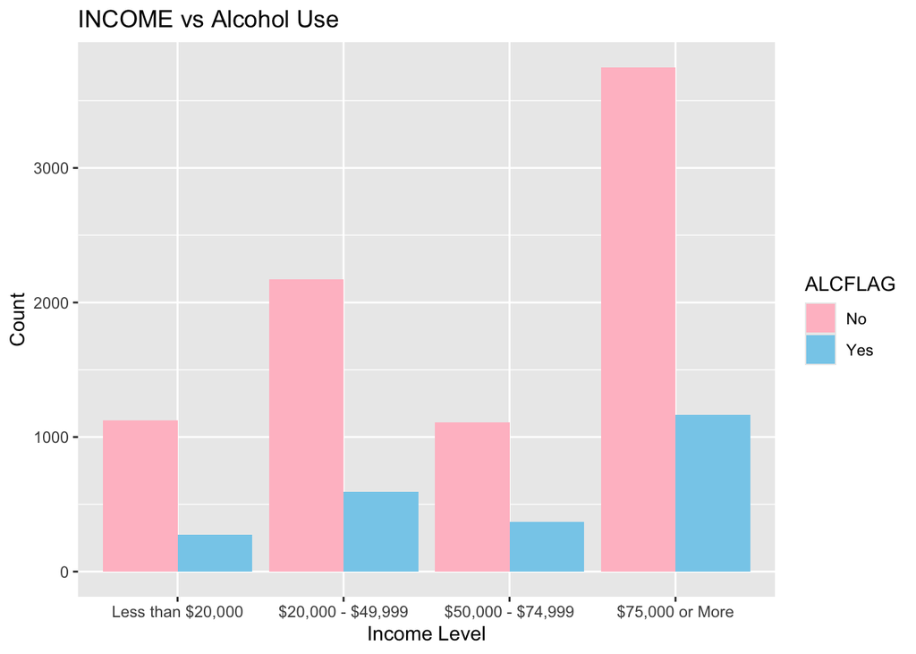

```r
# Data Visualisation
# Plot INCOME vs ALCFLAG (Alcohol Use)
ggplot(df, aes(x = INCOME, fill = ALCFLAG)) +
  geom_bar(position = "dodge", stat = "count") +
  labs(title = "INCOME vs Alcohol Use", x = "Income Level", y = "Count") +
  scale_fill_manual(values = c("Yes" = "skyblue", "No" = "pink"))
```

[figure not shown]

```r
# Plot PARCHKHW vs TOBFLAG
ggplot(df, aes(x = PARCHKHW, fill = TOBFLAG)) +
  geom_bar(position = "dodge", stat = "count") +
  labs(title = "Parents Arguing vs Tobacco Use", x = "Parents Arguing (Yes/No)", y = "Count") +
  scale_fill_manual(values = c("Yes" = "grey", "No" = "blue"))
```

[figure not shown]

```r
ggplot(df, aes(x = PRCHORE2, fill = MRJFLAG)) +
  geom_bar(position = "dodge", stat = "count") +
  labs(title = "Doing Household Chores vs Tobacco Use", x = "Household Chores (Yes/No)", y = "Count") +
  scale_fill_manual(values = c("Yes" = "yellow", "No" = "black"))
```

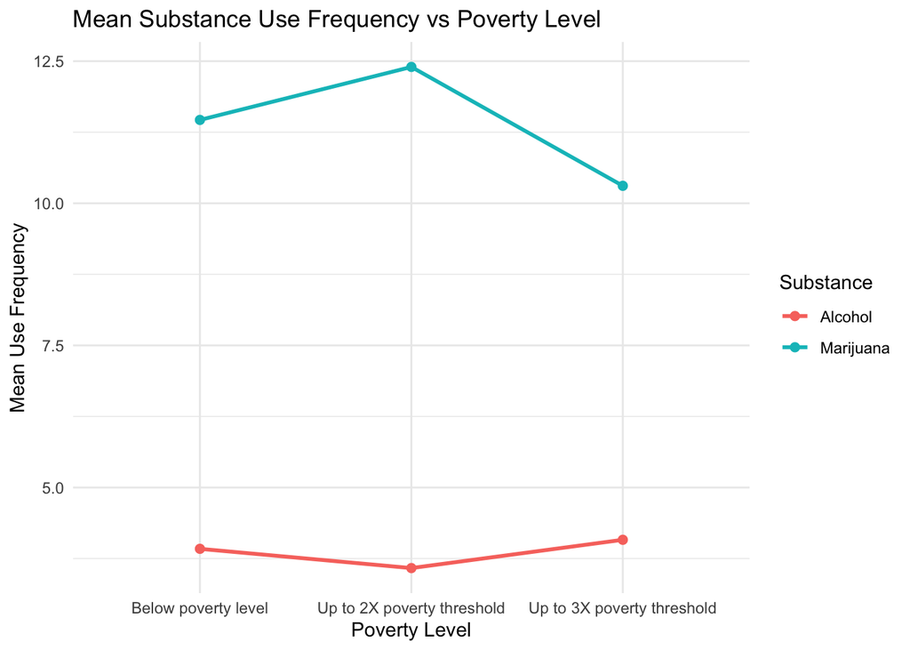

```r
# POVERTY vs IRALCFY, IRMJFY
df_line <- df %>%
  group_by(POVERTY3) %>%
  summarise(
    Alcohol = mean(IRALCFY, na.rm = TRUE),
    Marijuana = mean(IRMJFY, na.rm = TRUE),
    .groups = "drop"
  ) %>%
  pivot_longer(cols = c(Alcohol, Marijuana), names_to = "Substance", values_to = "MeanUsage")

ggplot(df_line, aes(x = POVERTY3, y = MeanUsage, color = Substance, group = Substance)) +
  geom_line(size = 1) +
  geom_point(size = 2) +
  labs(
    title = "Mean Substance Use Frequency vs Poverty Level",
    x = "Poverty Level",
    y = "Mean Use Frequency"
  ) +
  theme_minimal()
```

```r
#Train-Test Split (40%:60%)
# Set seed for reproducibility
set.seed(123)

train_indices <- sample(1:nrow(df), size = 0.4 * nrow(df))
df_train <- df[train_indices, ]
df_test <- df[-train_indices, ]
```

#### BINARY CLASSIFICATION

##### We use mincut, minsize, mindev so that the tree is more complex. There is not much variance in the data so without the three factors we end up with a stump. (Used Internet to get these factors in the tree function)

```r
# Set seed for reproducibility
set.seed(123)

# Factorization
df_train$MRJFLAG <- as.factor(df_train$MRJFLAG)
df_test$MRJFLAG <- as.factor(df_test$MRJFLAG)

# Binary Tree Implementation
binary_tree <- tree(MRJFLAG ~ PARCHKHW + PARHLPHW + PRCHORE2 +
                   PRLMTTV2 + PARLMTSN + PRGDJOB2 + PRPROUD2 + ARGUPAR +
                   PRMJEVR2 + PRMJMO + IMOTHER + IFATHER,
                   data = df_train, mincut = 7, minsize = 15, mindev = 0.001)

# Predictions on test data, confusion matrix and accuracy calculation
binary_pred <- predict(binary_tree, newdata = df_test, type = "class")
binary_confusion_matrix <- table(predicted = binary_pred, actual = df_test$MRJFLAG)
binary_accuracy <- sum(diag(binary_confusion_matrix)) / sum(binary_confusion_matrix)
cat("Accuracy BEFORE pruning:", binary_accuracy, "\n")
```

```
## Accuracy BEFORE pruning: 0.8494556
```

```r
print(binary_confusion_matrix)
```

```
##          actual
## predicted   No  Yes
##       No  5311  904
##       Yes   50   72
```

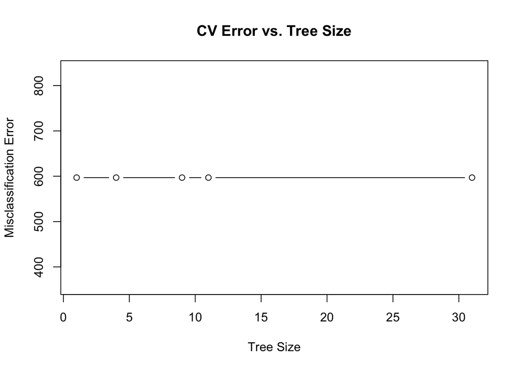

```r
# Cross - Validation for Optimization
binary_cv <- cv.tree(binary_tree, FUN = prune.misclass)

# Plot CV Error vs. Tree Size
plot(binary_cv$size, binary_cv$dev, type = "b",
     xlab = "Tree Size", ylab = "Misclassification Error",
     main = "CV Error vs. Tree Size")
```

##### The plot between Size and Deviance has only one error rate for all tree sizes! This can mean that the distribution of data in both the classes (Yes and No) is very imbalanced.

```r
table(df_train$MRJFLAG)
```

```
##
##   No  Yes
## 3610  614
```

```r
prop.table(table(df_train$MRJFLAG))
```

```
##
##        No       Yes
## 0.8546402 0.1453598
```

##### We see that the Yes class has very few observations as opposed to the No class. We can upsample and downsample respectively to get some decent results. Let us try resampling.

```r
# Set seed for reproducibility
set.seed(123)

# Factorization
df_train$MRJFLAG <- as.factor(df_train$MRJFLAG)
df_test$MRJFLAG <- as.factor(df_test$MRJFLAG)

# Downsampling the training set
df_train_bal <- downSample(x = df_train[, -which(names(df_train) == "MRJFLAG")],
                           y = df_train$MRJFLAG,
                           yname = "MRJFLAG")

# Checking class balance for Yes and No classes
print(prop.table(table(df_train_bal$MRJFLAG)))
```

```
##
##  No Yes
## 0.5 0.5
```

```r
# Binary Tree
binary_tree1 <- tree(MRJFLAG ~ PARCHKHW + PARHLPHW + PRCHORE2 +
                    PRLMTTV2 + PARLMTSN + PRGDJOB2 + PRPROUD2 + ARGUPAR +
                    PRMJEVR2 + PRMJMO + IMOTHER + IFATHER,
                    data = df_train_bal, mincut = 7, minsize = 15, mindev = 0.001)

# Predictions on test data, confusion matrix and accuracy calculation
binary_pred1 <- predict(binary_tree1, newdata = df_test, type = "class")
confusion_matrix1 <- table(Predicted = binary_pred1, Actual = df_test$MRJFLAG)
accuracy1 <- sum(diag(confusion_matrix1)) / sum(confusion_matrix1)
accuracy1
```

```
## [1] 0.7031718
```

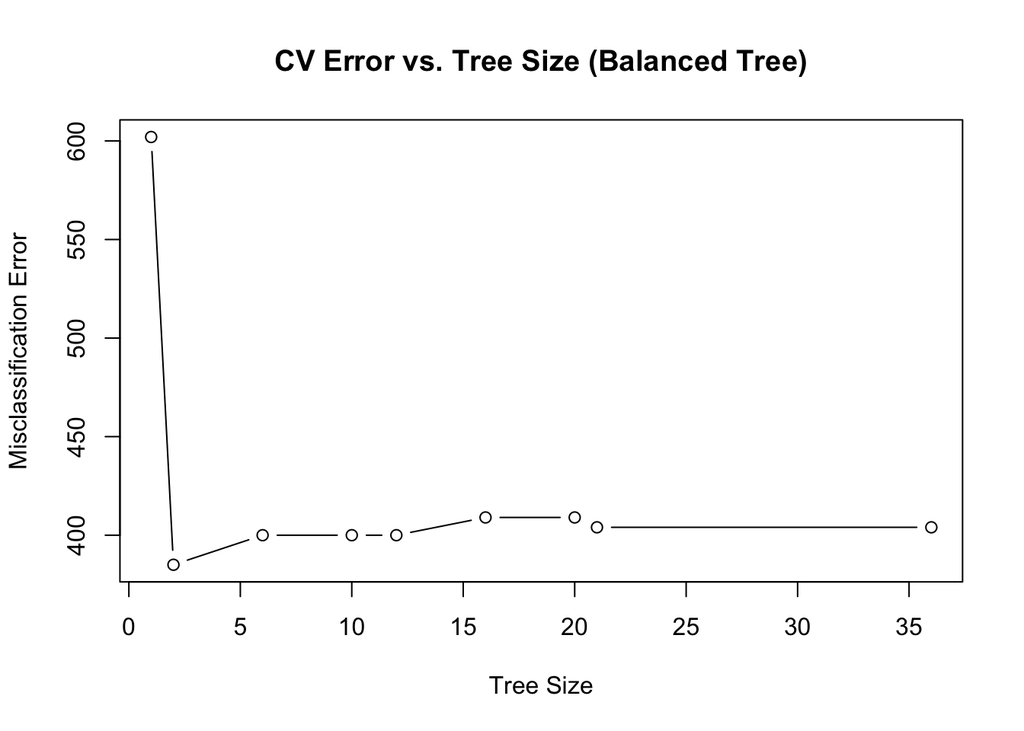

```r
# Cross Validation and its plot
binary_cv1 <- cv.tree(binary_tree1, FUN = prune.misclass)
plot(binary_cv1$size, binary_cv1$dev, type = "b",
     xlab = "Tree Size", ylab = "Misclassification Error",
     main = "CV Error vs. Tree Size (Balanced Tree)")
```

```r
# Set seed for reproducibility
set.seed(123)

# Pruning
binary_pruned1 <- prune.tree(binary_tree1, best = 15)

# Predictions on test data, confusion matrix and accuracy calculation
binary_pred2 <- predict(binary_pruned1, newdata = df_test, type = "class")
confusion_matrix2 <- table(Predicted = binary_pred2, Actual = df_test$MRJFLAG)
accuracy2 <- sum(diag(confusion_matrix2)) / sum(confusion_matrix2)
accuracy2
```

```
## [1] 0.7227395
```

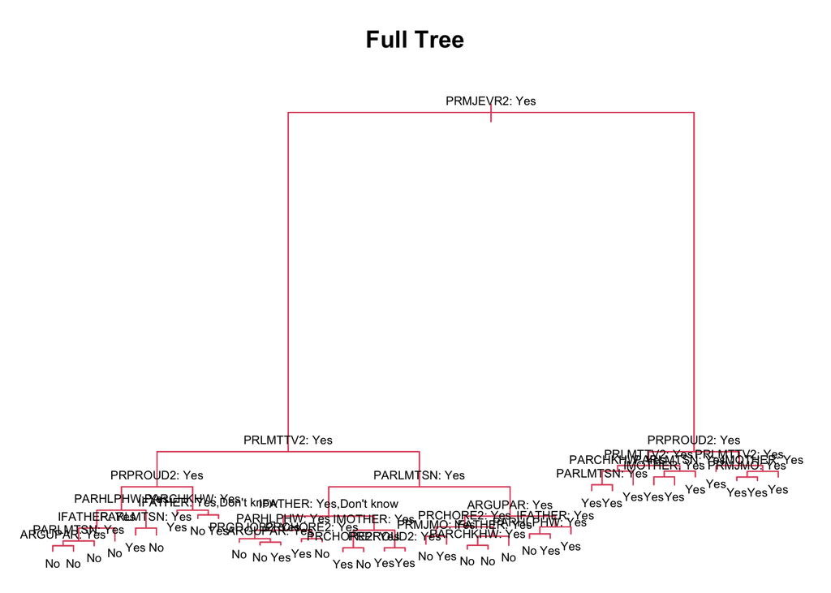

```r
# Plotting Trees
# Unpruned Tree
par(mfrow = c(1, 1), mar = c(1, 1, 4, 1))
plot(binary_tree1, col = 2, lty = 1)
text(binary_tree1, pretty = 0, cex = 0.6)
title("Full Tree", line = 2)
```

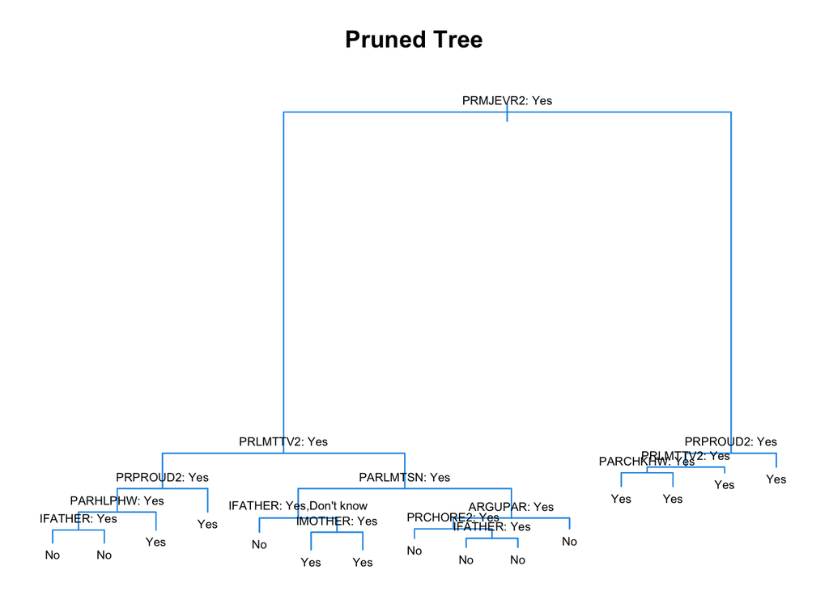

```r
# Pruned Tree
par(mfrow = c(1, 1), mar = c(1, 1, 4, 1))
plot(binary_pruned1, col = 4, lty = 1)
text(binary_pruned1, pretty = 0, cex = 0.6)
title("Pruned Tree", line = 2)
```

##### The accuracy before and after pruning is 0.7031718 and 0.7227395, respectively. ThUS we seem to have successfully optimised our tree. We could have also tried bagging and boosting on our binary tree, to optimise it even further.

#### MULTI-CLASS CLASSIFICATION

##### Our response variable is MRJYDAYS which has classes from 1-6, 6 standing for non-user and no past year use. Thus, we eliminate class 6 from our data, to get better insights. We also remove NA values because bagging does not work with NA values in the dataset.

[figure not shown]

```r
# Set seed for reproducibility
set.seed(123)

# Factorization and Filtering of Data
df_train <- subset(df_train, MRJYDAYS %in% 1:5)
df_test <- subset(df_test, MRJYDAYS %in% 1:5)
df_train$MRJYDAYS <- factor(df_train$MRJYDAYS)
df_test$MRJYDAYS <- factor(df_test$MRJYDAYS)

# Remove NA values
df_train <- na.omit(df_train)
df_test <- na.omit(df_test)

# Multi-Class Tree
multi_tree <- tree(MRJYDAYS ~ PARCHKHW + PARHLPHW + PRCHORE2 + PRLMTTV2 +
                       PARLMTSN + PRGDJOB2 + PRPROUD2 + ARGUPAR + PRMJEVR2 +
                       PRMJMO + IMOTHER + IFATHER + INCOME + GOVTPROG +
                       POVERTY3 + PRGDJOB2 + PRLMTTV2,
                   data = df_train,
                   control = tree.control(nobs = nrow(df_train), mincut = 5, minsize = 10, mindev = 0.0001))

# Plot the tree
plot(multi_tree)
text(multi_tree, pretty = 0)
```

```r
# Predictions on test data, confusion matrix and accuracy calculation
multi_pred <- predict(multi_tree, df_test, type = "class")
multi_cm <- table(Predicted = multi_pred, Actual = df_test$MRJYDAYS)
accuracy_multi <- sum(diag(multi_cm)) / sum(multi_cm)
accuracy_multi
```

```
## [1] 0.252505
```

```r
# Bagging (mtry = 17, since there are 17 predictions)
multi_bag <- randomForest(MRJYDAYS ~ PARCHKHW + PARHLPHW + PRCHORE2 + PRLMTTV2 +
                       PARLMTSN + PRGDJOB2 + PRPROUD2 + ARGUPAR + PRMJEVR2 +
                       PRMJMO + IMOTHER + IFATHER + INCOME + GOVTPROG +
                       POVERTY3 + PRGDJOB2 + PRLMTTV2,
                         data = df_train,
                         importance = TRUE,
                         mtry = 17,
                         ntree = 100,
                         na.action = na.omit)
```

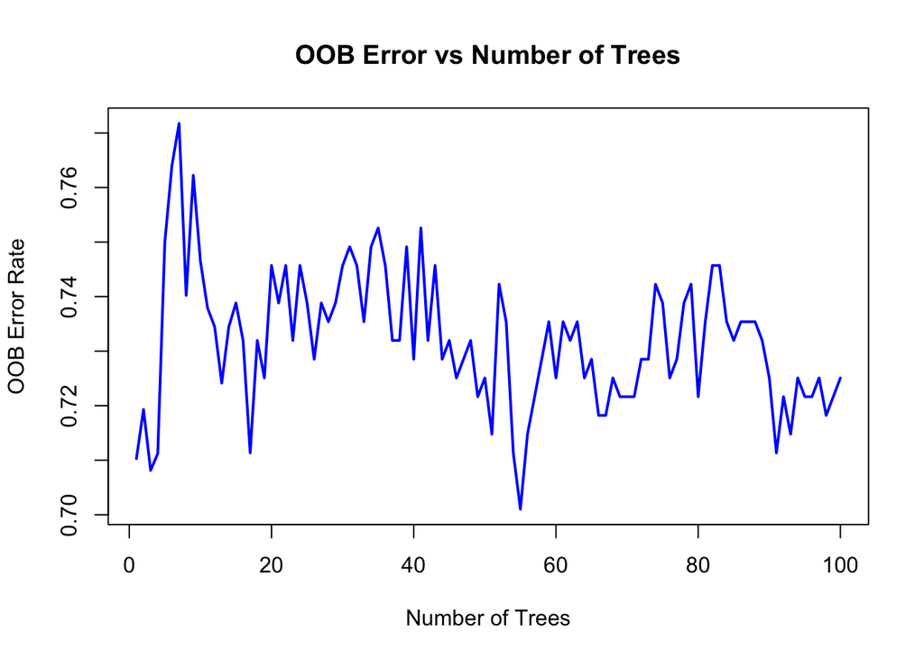

```r
# Extract OOB error rate for each tree
OOB_ERROR <- multi_bag$err.rate[, "OOB"]

# Plot OOB error vs number of trees
plot(OOB_ERROR, type = "l", col = "blue", lwd = 2,
     xlab = "Number of Trees", ylab = "OOB Error Rate",
     main = "OOB Error vs Number of Trees")
```

```r
# Bagging with tuning of mtry and ntree parameters for optimal accuracy
multi_bag1 <- randomForest(MRJYDAYS ~ PARCHKHW + PARHLPHW + PRCHORE2 + PRLMTTV2 +
                       PARLMTSN + PRGDJOB2 + PRPROUD2 + ARGUPAR + PRMJEVR2 +
                       PRMJMO + IMOTHER + IFATHER + INCOME + GOVTPROG +
                       POVERTY3 + PRGDJOB2 + PRLMTTV2,
                         data = df_train,
                         importance = TRUE,
                         mtry = 8,
                         ntree = 25,
                         na.action = na.omit)

# Predictions on test data, confusion matrix and accuracy calculation
multi_bag_pred1 <- predict(multi_bag1, df_test)
multi_bag_cm1 <- table(Predicted = multi_bag_pred1, Actual = df_test$MRJYDAYS)
accuracy_multi_bag1 <- sum(diag(multi_bag_cm1)) / sum(multi_bag_cm1)
accuracy_multi_bag1
```

```
## [1] 0.2765531
```

```r
# Bagging with tuning of mtry and ntree parameters for optimal accuracy
multi_bag2 <- randomForest(MRJYDAYS ~ PARCHKHW + PARHLPHW + PRCHORE2 + PRLMTTV2 +
                       PARLMTSN + PRGDJOB2 + PRPROUD2 + ARGUPAR + PRMJEVR2 +
                       PRMJMO + IMOTHER + IFATHER + INCOME + GOVTPROG +
                       POVERTY3 + PRGDJOB2 + PRLMTTV2,
                         data = df_train,
                         importance = TRUE,
                         mtry = 5,
                         ntree = 25,
                         na.action = na.omit)

# Predictions on test data, confusion matrix and accuracy calculation
multi_bag_pred2 <- predict(multi_bag2, df_test)
multi_bag_cm2 <- table(Predicted = multi_bag_pred2, Actual = df_test$MRJYDAYS)
accuracy_multi_bag2 <- sum(diag(multi_bag_cm2)) / sum(multi_bag_cm2)
accuracy_multi_bag2
```

```
## [1] 0.2945892
```

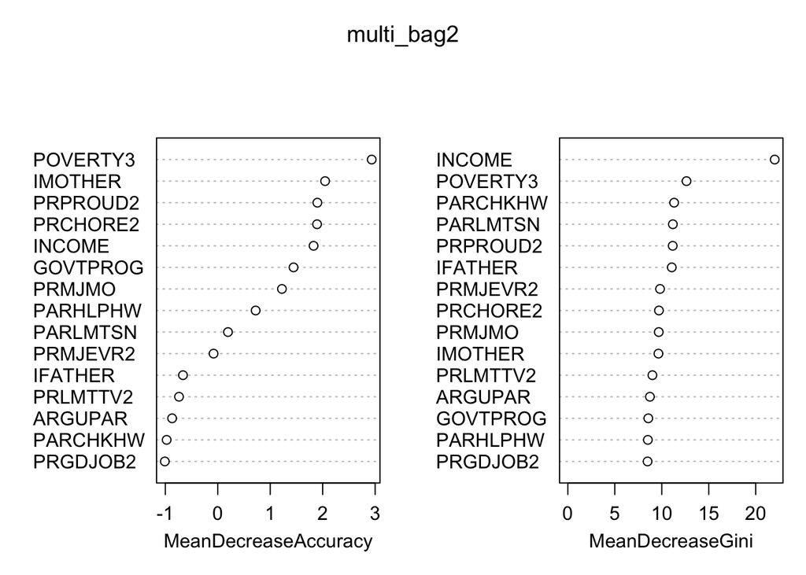

```r
varImpPlot(multi_bag2)
```

##### The graph for OOB vs Number of Trees is not something like we have seen in class, so keeping both parameters in mind, I chose n = 25. Then we played around with mtry and got improvements on our accuracy. We can tune these parameters further to find better accuracy.

#### REGRESSION

##### For regression we make sure our response variable is numeric and plot MSEs instead of accuracies, as it is preferred for regression models.

```r
# Set seed for reproducibility
set.seed(123)

# Ensuring IRMJFY is numeric (for regression)
df_train$IRMJFY <- as.numeric(df_train$IRMJFY)
df_test$IRMJFY <- as.numeric(df_test$IRMJFY)

# Regression Tree
reg_tree_model <- tree(IRMJFY ~ PARCHKHW + PARHLPHW + PRCHORE2 + PRLMTTV2 +
                       PARLMTSN + PRGDJOB2 + PRPROUD2 + ARGUPAR + PRMJEVR2 +
                       PRMJMO + IMOTHER + IFATHER + INCOME + GOVTPROG +
                       POVERTY3 + PRGDJOB2 + PRLMTTV2, data = df_train)
reg_tree_model
```

```
## node), split, n, deviance, yval
##       * denotes terminal node
##
## 1) root 291 2832000  79.23
##   2) GOVTPROG: Yes 101 1110000 101.90
##     4) PRLMTTV2: Yes 19  139700  61.16
##       8) PRGDJOB2: Yes 14   23800  33.07 *
##       9) PRGDJOB2: No 5   73940 139.80 *
##     5) PRLMTTV2: No 82  931900 111.30 *
##   3) GOVTPROG: No 190 1643000  67.21 *
```

```r
# Predictions on test set
pred_tree <- predict(reg_tree_model, df_test)

# MSE for Regression Tree
mse_tree <- mean((pred_tree - df_test$IRMJFY)^2)
cat("MSE for Regression Tree:", round(mse_tree, 4), "\n")
```

```
## MSE for Regression Tree: 12818.46
```

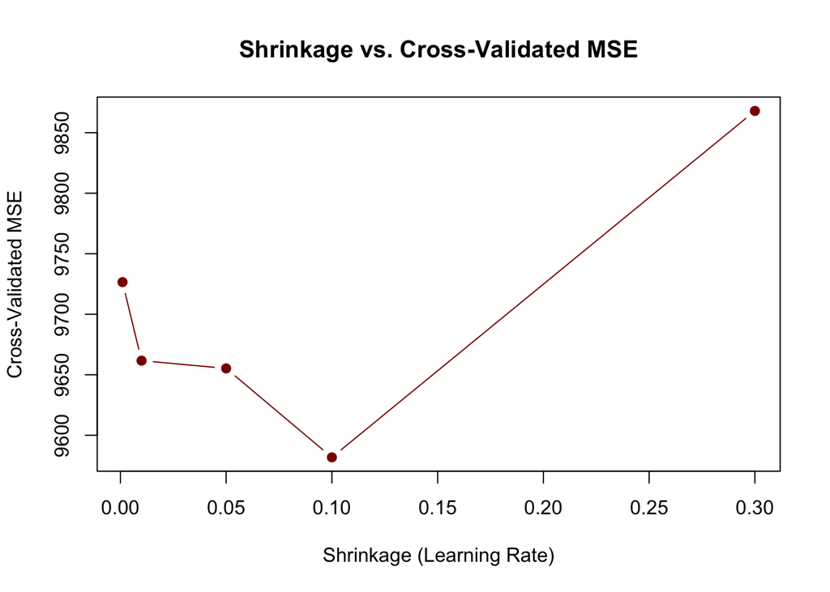

```r
# Boosting with different shrinkage values
reg_boost1 <- gbm(IRMJFY ~ PARCHKHW + PARHLPHW + PRCHORE2 + PRLMTTV2 +
                     PARLMTSN + PRGDJOB2 + PRPROUD2 + ARGUPAR + PRMJEVR2 +
                     PRMJMO + IMOTHER + IFATHER + INCOME + GOVTPROG +
                     POVERTY3 + PRGDJOB2 + PRLMTTV2,
                     data = df_train,
                     distribution = "gaussian",
                     interaction.depth = 3,
                     shrinkage = 0.001,
                     n.trees = 250,
                     cv.folds = 5)  # 5-fold cross-validation

reg_boost2 <- gbm(IRMJFY ~ PARCHKHW + PARHLPHW + PRCHORE2 + PRLMTTV2 +
                     PARLMTSN + PRGDJOB2 + PRPROUD2 + ARGUPAR + PRMJEVR2 +
                     PRMJMO + IMOTHER + IFATHER + INCOME + GOVTPROG +
                     POVERTY3 + PRGDJOB2 + PRLMTTV2,
                     data = df_train,
                     distribution = "gaussian",  # For regression
                     n.trees = 250,              # Number of boosting iterations
                     interaction.depth = 3,      # Max depth of each tree
                     shrinkage = 0.01,
                     cv.folds = 5)

reg_boost3 <- gbm(IRMJFY ~ PARCHKHW + PARHLPHW + PRCHORE2 + PRLMTTV2 +
                     PARLMTSN + PRGDJOB2 + PRPROUD2 + ARGUPAR + PRMJEVR2 +
                     PRMJMO + IMOTHER + IFATHER + INCOME + GOVTPROG +
                     POVERTY3 + PRGDJOB2 + PRLMTTV2,
                     data = df_train,
                     distribution = "gaussian",  # For regression
                     n.trees = 250,              # Number of boosting iterations
                     interaction.depth = 3,      # Max depth of each tree
                     shrinkage = 0.05,
                     cv.folds = 5)

reg_boost4 <- gbm(IRMJFY ~ PARCHKHW + PARHLPHW + PRCHORE2 + PRLMTTV2 +
                     PARLMTSN + PRGDJOB2 + PRPROUD2 + ARGUPAR + PRMJEVR2 +
                     PRMJMO + IMOTHER + IFATHER + INCOME + GOVTPROG +
                     POVERTY3 + PRGDJOB2 + PRLMTTV2,
                     data = df_train,
                     distribution = "gaussian",  # For regression
                     n.trees = 250,              # Number of boosting iterations
                     interaction.depth = 3,      # Max depth of each tree
                     shrinkage = 0.1,
                     cv.folds = 5)

reg_boost5 <- gbm(IRMJFY ~ PARCHKHW + PARHLPHW + PRCHORE2 + PRLMTTV2 +
                     PARLMTSN + PRGDJOB2 + PRPROUD2 + ARGUPAR + PRMJEVR2 +
                     PRMJMO + IMOTHER + IFATHER + INCOME + GOVTPROG +
                     POVERTY3 + PRGDJOB2 + PRLMTTV2,
                     data = df_train,
                     distribution = "gaussian",  # For regression
                     n.trees = 250,              # Number of boosting iterations
                     interaction.depth = 3,      # Max depth of each tree
                     shrinkage = 0.3,
                     cv.folds = 5)

# MSE
mse1 <- min(reg_boost1$cv.error, na.rm = TRUE)
mse2 <- min(reg_boost2$cv.error, na.rm = TRUE)
mse3 <- min(reg_boost3$cv.error, na.rm = TRUE)
mse4 <- min(reg_boost4$cv.error, na.rm = TRUE)
mse5 <- min(reg_boost5$cv.error, na.rm = TRUE)

# Shrinkage values and MSE values
shrinkage_values <- c(0.001, 0.01, 0.05, 0.1, 0.3)
mse_values <- c(mse1, mse2, mse3, mse4, mse5)

# Plot MSE vs. Shrinkage
plot(shrinkage_values, mse_values, type = "b", pch = 19, col = "darkred",
     xlab = "Shrinkage (Learning Rate)",
     ylab = "Cross-Validated MSE",
     main = "Shrinkage vs. Cross-Validated MSE")
```

##### We see from the plot that the boosting model with 0.1 shrinkage value has minimum MSE. Thus model 4 would be an optimal model.